# Assignment 5: House Price Prediction, Chicago

MUSA 5080 · Team assignment

Author

Team Red-Purple: Jonah, Luca, Rita, Ryska

Published

November 6, 2026

### Background: The goal of our model:

Chicago has long faced housing affordability challenges, and home prices vary considerably across the city’s neighborhoods. Understanding what drives these differences is essential to understanding the local housing market. In this project, we examine the factors influencing single-family home sale prices in Chicago from 2023 to 2025 and develop a predictive model to estimate prices for properties without recent sales. This model can help us explore how property characteristics, proximity to amenities, and location shape home values and provide insights into the challenges of equitable property assessment. We want to focus on the phenomena of “The Tax Divide,” meaning whether lower-value homes were assessed at higher shares of their worth (and are over-taxed) than expensive one in Chicago.

## Part 0: Setup (provided)

```r
check_na <- function(formula, df) {
  vars <- all.vars(formula)
  bad <- vars[sapply(vars, function(v) any(is.na(df[[v]])))]
  if (length(bad) > 0) {
    stop("These variables have NAs: ", paste(bad, collapse = ", "),
         ". Fill them or choose another variable (Rule 1).")
  }
}


cv_rmse <- function(formula, data) {
  df <- if (inherits(data, "sf")) st_drop_geometry(data) else data
  check_na(formula, df)
  set.seed(5080)
  fit <- train(formula, data = df, method = "lm",
               trControl = trainControl(method = "cv", number = 10))
  fit$results$RMSE
}


cv_pred <- function(formula, data) {
  df <- if (inherits(data, "sf")) st_drop_geometry(data) else data
  check_na(formula, df)
  set.seed(5080)
  fit <- train(formula, data = df, method = "lm",
               trControl = trainControl(method = "cv", number = 10,
                                        savePredictions = "final"))
  fit$pred %>% arrange(rowIndex) %>% pull(pred)
}


socrata_get <- function(dataset, where, select = NULL, limit = 200000) {
  where <- str_squish(where)
  q <- paste0("$where=", URLencode(where, reserved = TRUE), "&$limit=", limit)
  if (!is.null(select)) q <- paste0(q, "&$select=", URLencode(str_squish(select), reserved = TRUE))
  url <- paste0("https://data.cityofchicago.org/resource/", dataset, ".geojson?", q)
  tmp <- tempfile(fileext = ".geojson")
  resp <- tryCatch(download.file(url, tmp, quiet = TRUE), error = function(e) e)
  if (inherits(resp, "error")) stop("Portal request failed. Open this URL in a browser to see why:\n", url)
  st_read(tmp, quiet = TRUE)
}
```

### Load both files together (provided)

We use EPSG:3435 (NAD83 / Illinois East) as the projected coordinate reference system for spatial analysis. The dataset provided for this assignment has already been divided into training and test sets, which we use for model development and prediction, respectively.

```r
all_sales <- bind_rows(
  read_csv("assignments/assignment5_files/chicago_train.csv", show_col_types = FALSE) %>% mutate(split = "train"),
  read_csv("assignments/assignment5_files/chicago_test.csv",  show_col_types = FALSE) %>% mutate(split = "test")
) %>%
  st_as_sf(coords = c("lon", "lat"), crs = 4326) %>%
  st_transform(3435)            # Illinois East State Plane, feet


all_sales %>% st_drop_geometry() %>% count(split)
```

```
# A tibble: 2 × 2
  split     n
  <chr> <int>
1 test   5789
2 train 23200
```

Useful sources: the [Chicago Data Portal](https://data.cityofchicago.org) (find a dataset’s ID under its API button), the Census via `tidycensus`, and Cook County’s open data.

## Part 1: Clean and Explore

We first examined the dataset, focusing on variables related to the physical characteristics of each house. To better understand how property characteristics differ across price levels, we divided homes into three categories based on sale price quartiles: low-priced homes (bottom 25%), medium-priced homes (middle 50%), and high-priced homes (top 25%).

Our initial spatial analysis revealed a clear geographic pattern: low-priced homes are concentrated primarily in the South Side of Chicago, while high-priced homes are more prevalent in the northern part of the city, particularly near Lake Michigan. This pattern suggested that location may play an important role in determining home sale prices, motivating us to investigate tract level and neighborhood level factors in our predictive model.

```r
summary(all_sales$sale_price)
```

```
    Min.  1st Qu.   Median     Mean  3rd Qu.     Max.     NA's
   10373   184500   302950   442784   479900 21800000     5789
```

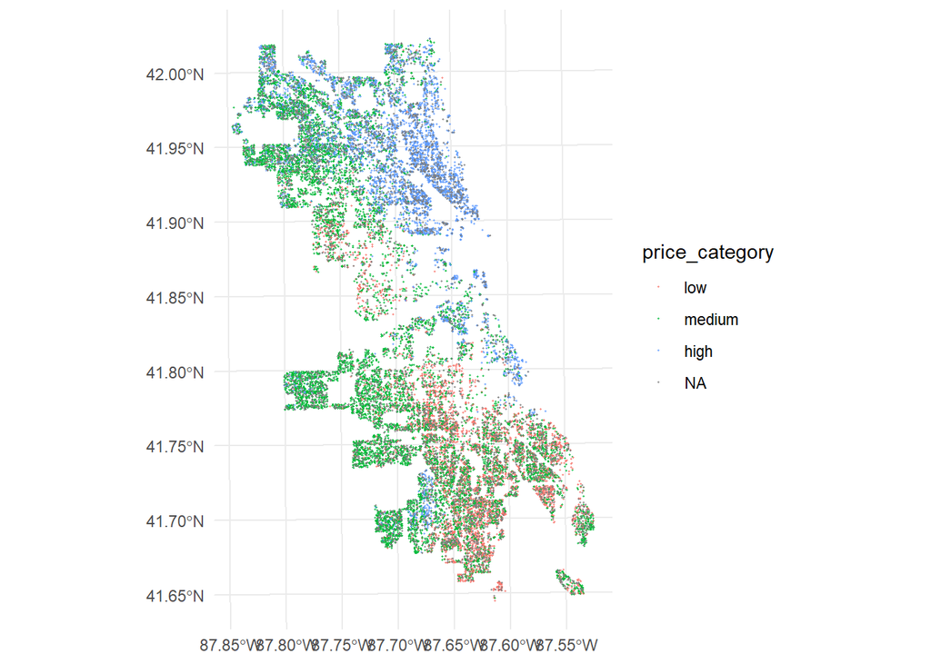

```r
all_sales <- all_sales %>%
  mutate(
    price_category = cut(
      sale_price,
      breaks = c(0, 180000, 469000, Inf),
      labels = c("low", "medium", "high")
    )
  )

ggplot(all_sales) +
  geom_sf(aes(color = price_category), alpha = 0.7, size = 0.2) +
  theme_minimal()
```

We then examined the distributions of key housing characteristics to understand their relationships with sale prices.

- Building size: Sale prices show a generally positive, linear relationship with building size (measured in thousands of square feet), with larger homes tending to sell for more.
- Building age: The relationship appears nonlinear, with both newer and older buildings associated with higher sale prices.
- Number of bedrooms: Bedroom counts are unevenly distributed across the dataset. We therefore considered re-categorizing this variable to better represent differences in housing types and improve model performance.

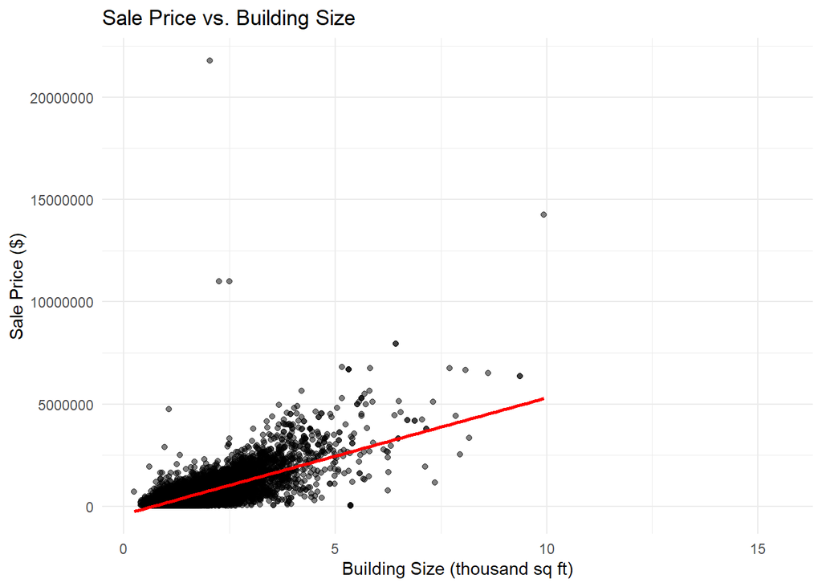

```r
ggplot(all_sales, aes(x = building_000sf, y = sale_price)) +
  geom_point(alpha = 0.5) +
  geom_smooth(method = "lm", se = TRUE, color = "red") +
  labs(
    title = "Sale Price vs. Building Size",
    x = "Building Size (thousand sq ft)",
    y = "Sale Price ($)"
  ) +
  theme_minimal()
```

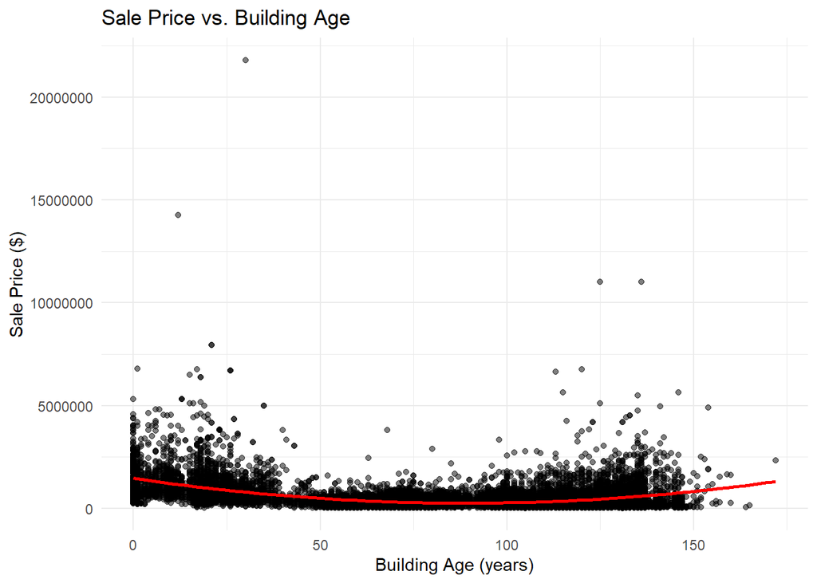

```r
ggplot(all_sales, aes(x = building_age, y = sale_price)) +
  geom_point(alpha = 0.5) +
  geom_smooth(
    method = "lm",
    formula = y ~ x + I(x^2),
    se = TRUE,
    color = "red"
  ) +
  labs(
    title = "Sale Price vs. Building Age",
    x = "Building Age (years)",
    y = "Sale Price ($)"
  ) +
  theme_minimal()
```

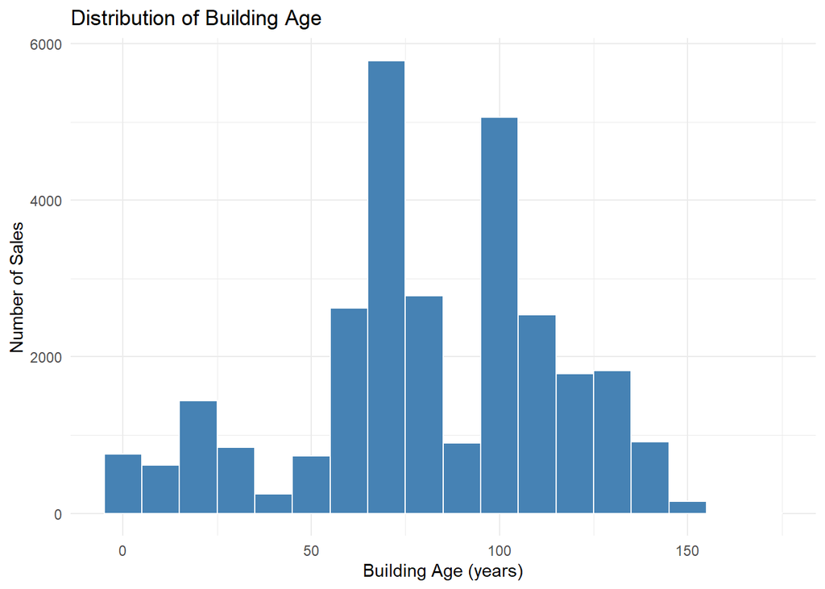

```r
ggplot(all_sales, aes(x = building_age)) +
  geom_histogram(binwidth = 10, fill = "steelblue", color = "white") +
  labs(
    title = "Distribution of Building Age",
    x = "Building Age (years)",
    y = "Number of Sales"
  ) +
  theme_minimal()
```

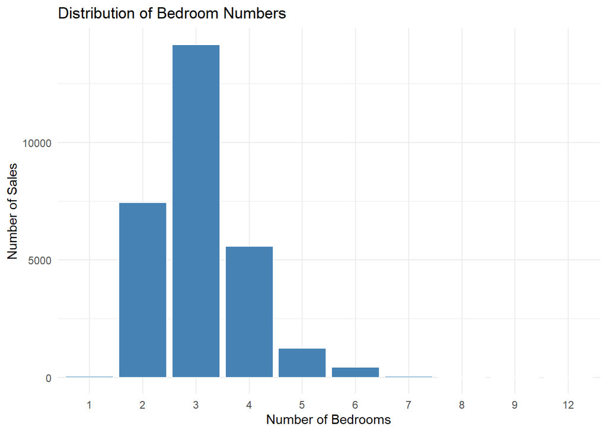

```r
ggplot(all_sales, aes(x = factor(num_bedrooms))) +
  geom_bar(fill = "steelblue", color = "white") +
  labs(
    title = "Distribution of Bedroom Numbers",
    x = "Number of Bedrooms",
    y = "Number of Sales"
  ) +
  theme_minimal()
```

### Baseline Model

We used a box plot to check that houses that have more bedrooms generally had a higher sale price.

```r
all_sales <- all_sales %>%
  mutate(building_sf = building_000sf *1000,
        lotsize_sqft = lotsize_acre * 53650)
```

```r
all_sales <- all_sales %>%
  mutate(
    Cat_bedroom_num = case_when(
      num_bedrooms <= 2 ~ "1-2 bedrooms",
      num_bedrooms == 3 ~ "3 bedrooms",
      num_bedrooms >= 4 & num_bedrooms <= 5 ~ "4-5 bedrooms",
      num_bedrooms >= 6 ~ "6+ bedrooms",
      TRUE ~ NA_character_
    ),
    Cat_bedroom_num = factor(
      Cat_bedroom_num,
      levels = c(
        "1-2 bedrooms",
        "3 bedrooms",
        "4-5 bedrooms",
        "6+ bedrooms"
      )
    )
  )

all_sales %>%
  count(Cat_bedroom_num, .drop = FALSE, name = "num_houses")
```

```
Simple feature collection with 4 features and 2 fields
Geometry type: MULTIPOINT
Dimension:     XY
Bounding box:  xmin: 1116740 ymin: 1814027 xmax: 1205030 ymax: 1951538
Projected CRS: NAD83 / Illinois East (ftUS)
# A tibble: 4 × 3
  Cat_bedroom_num num_houses                                            geometry
* <fct>                <int>                       <MULTIPOINT [US_survey_foot]>
1 1-2 bedrooms          7485 ((1118099 1929160), (1118964 1928709), (1119443 19…
2 3 bedrooms           14167 ((1116740 1929929), (1116903 1930219), (1116904 19…
3 4-5 bedrooms          6820 ((1117022 1929288), (1117189 1929262), (1117214 19…
4 6+ bedrooms            517 ((1117756 1929594), (1123623 1935489), (1123850 19…
```

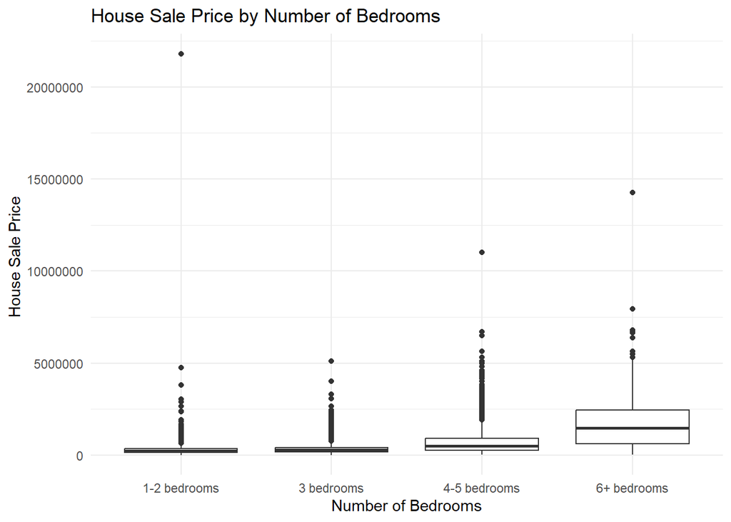

```r
ggplot(all_sales, aes(x = Cat_bedroom_num, y = sale_price)) +
  geom_boxplot() +
  labs(
    title = "House Sale Price by Number of Bedrooms",
    x = "Number of Bedrooms",
    y = "House Sale Price "
  ) +
  theme_minimal()
```

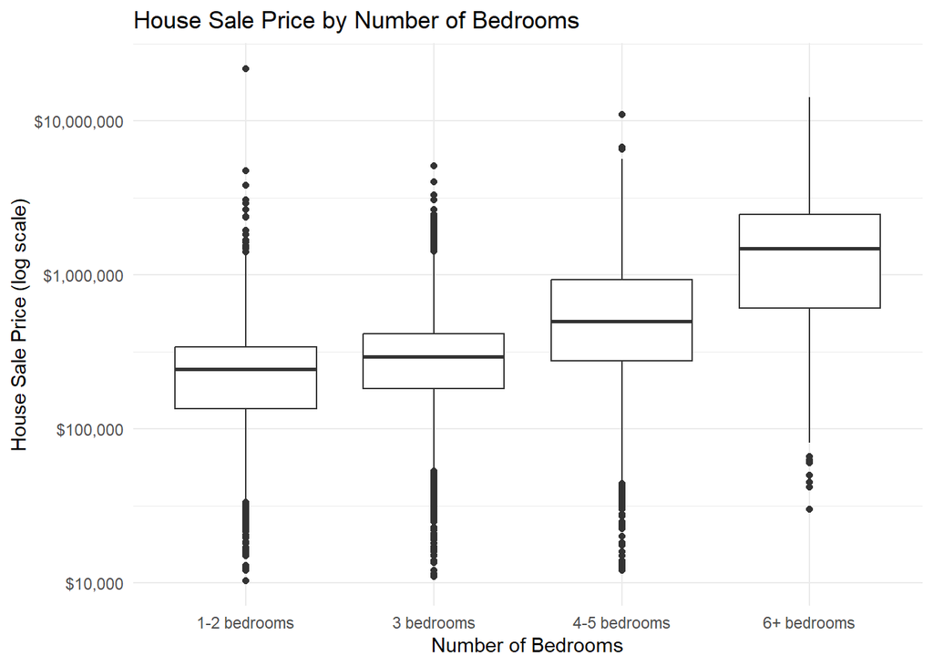

```r
ggplot(all_sales, aes(x = Cat_bedroom_num, y = sale_price)) +
  geom_boxplot() +
  scale_y_log10(labels = scales::label_dollar()) +
  labs(
    title = "House Sale Price by Number of Bedrooms",
    x = "Number of Bedrooms",
    y = "House Sale Price (log scale)"
  ) +
  theme_minimal()
```

```r
train_set <- all_sales %>%
  filter(split == "train")
test_set <- all_sales %>%
  filter(split == "test")

f1 <- sale_price ~ I(building_age^2) + building_age + building_sf + Cat_bedroom_num

m1 <- lm(f1, data = train_set)
summary(m1)
```

```
Call:
lm(formula = f1, data = train_set)

Residuals:
     Min       1Q   Median       3Q      Max
-2706631  -140895    -5377   122416 20821511

Coefficients:
                               Estimate  Std. Error t value
(Intercept)                  110398.012   14460.379   7.635
I(building_age^2)                48.727       1.799  27.086
building_age                  -9025.722     284.035 -31.777
building_sf                     539.945       4.903 110.121
Cat_bedroom_num3 bedrooms   -122721.234    5902.524 -20.791
Cat_bedroom_num4-5 bedrooms -181389.735    8234.943 -22.027
Cat_bedroom_num6+ bedrooms    36018.344   21400.432   1.683
                                        Pr(>|t|)
(Intercept)                   0.0000000000000235 ***
I(building_age^2)           < 0.0000000000000002 ***
building_age                < 0.0000000000000002 ***
building_sf                 < 0.0000000000000002 ***
Cat_bedroom_num3 bedrooms   < 0.0000000000000002 ***
Cat_bedroom_num4-5 bedrooms < 0.0000000000000002 ***
Cat_bedroom_num6+ bedrooms                0.0924 .
---
Signif. codes:  0 '***' 0.001 '**' 0.01 '*' 0.05 '.' 0.1 ' ' 1

Residual standard error: 356500 on 23193 degrees of freedom
Multiple R-squared:  0.5739,    Adjusted R-squared:  0.5737
F-statistic:  5205 on 6 and 23193 DF,  p-value: < 0.00000000000000022
```

```r
coords_train <- st_coordinates(train_set)
w_knn <- nb2listw(knn2nb(knearneigh(coords_train, k = 5)), style = "W")


train_set$resid_m1 <- residuals(m1)

mc <- moran.mc(train_set$resid_m1, w_knn, nsim = 499)
mc$statistic
```

```
statistic
0.3560954
```

```r
mc$p.value
```

```
[1] 0.002
```

```r
model_log <- model_log %>%
  add_row(model = "m1", added = "Baseline",
          cv_rmse = cv_rmse(f1, train_set),
          morans_i = mc$statistic,
          moran_p = mc$p.value,
          notes = "Squared building age, building square footage, and number of bedrooms.")

model_log
```

```
# A tibble: 1 × 6
  model added    cv_rmse morans_i moran_p notes
  <chr> <chr>      <dbl>    <dbl>   <dbl> <chr>
1 m1    Baseline 349355.    0.356   0.002 Squared building age, building square…
```

The CV-RMSE for the Baseline model is $349,355, and Moran’s I is 0.356.

This suggests that nearby properties tend to have similar prediction errors, meaning the baseline model may not fully capture the spatial patterns underlying Chicago’s housing market.

### Modified Baseline: added fireplace + lot size

We then expanded the baseline model by incorporating two additional housing characteristics: the number of fireplaces and lot size. Lot sizes are concentrated within a relatively narrow range, so we applied a log transformation to capture their distribution better. For fireplaces, the data includes a sufficient number of homes with one or more fireplaces, so we thought it important to add it to our model.

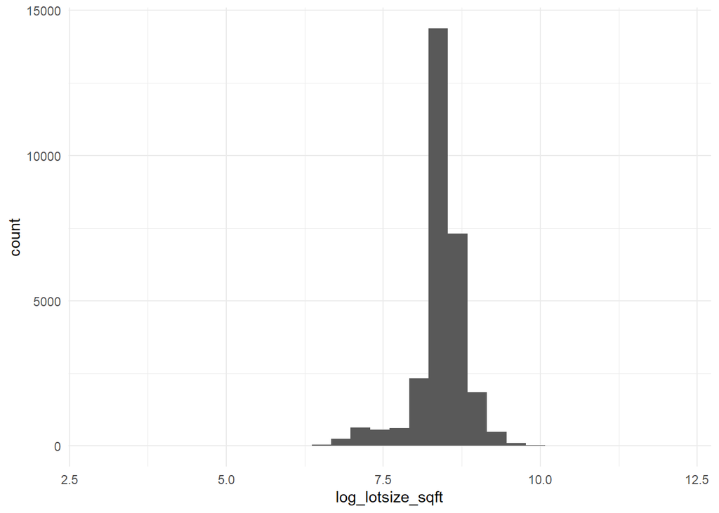

```r
all_sales <- all_sales %>%
  filter(!is.na(lotsize_sqft),
         !is.na(num_fireplaces)
         # add !is.na() for each baseline predictor like in the in-class lab
         )


all_sales <- all_sales %>%
  mutate(log_lotsize_sqft = log1p(lotsize_sqft))


ggplot(all_sales, aes(x = log_lotsize_sqft)) + geom_histogram(bins = 30) + theme_minimal()
```

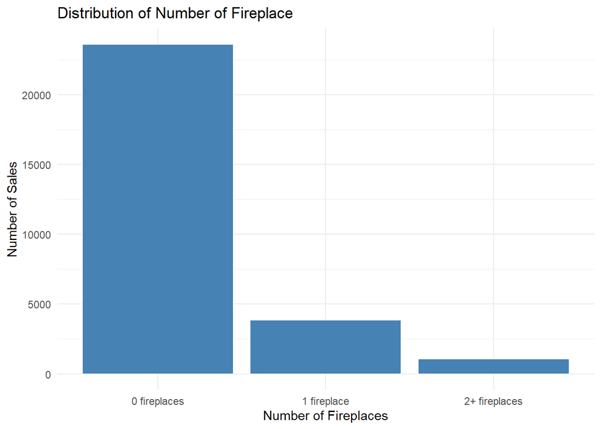

```r
all_sales <- all_sales %>%
  mutate(
    Cat_fireplaces_num = case_when(
      num_fireplaces < 1 ~ "0 fireplaces",
      num_fireplaces == 1 ~ "1 fireplace",
      num_fireplaces > 1 ~ "2+ fireplaces",
      TRUE ~ NA_character_
    ),
    Cat_fireplaces_num = factor(
      Cat_fireplaces_num,
      levels = c(
        "0 fireplaces",
        "1 fireplace",
        "2+ fireplaces"
      )
    )
  )


ggplot(all_sales, aes(x = factor(Cat_fireplaces_num))) +
  geom_bar(fill = "steelblue", color = "white") +
  labs(
    title = "Distribution of Number of Fireplace",
    x = "Number of Fireplaces",
    y = "Number of Sales"
  ) +
  theme_minimal()
```

```r
train_set <- all_sales %>%
  filter(split == "train")

f2 <- sale_price ~ I(building_age^2) + building_age + Cat_bedroom_num + Cat_fireplaces_num + building_sf + log_lotsize_sqft

m2 <- lm(f2, data = train_set)
summary(m2)
```

```
Call:
lm(formula = f2, data = train_set)

Residuals:
     Min       1Q   Median       3Q      Max
-2493502  -136238    -5275   119870 20813093

Coefficients:
                                   Estimate  Std. Error t value
(Intercept)                      358342.124   49874.819   7.185
I(building_age^2)                    49.862       2.048  24.345
building_age                      -9087.252     339.061 -26.801
Cat_bedroom_num3 bedrooms       -107102.298    5762.023 -18.588
Cat_bedroom_num4-5 bedrooms     -165331.506    8143.594 -20.302
Cat_bedroom_num6+ bedrooms       -17368.571   21979.663  -0.790
Cat_fireplaces_num1 fireplace     31443.469    7407.045   4.245
Cat_fireplaces_num2+ fireplaces  373351.688   13817.655  27.020
building_sf                         491.680       5.169  95.122
log_lotsize_sqft                 -24778.451    6453.486  -3.840
                                            Pr(>|t|)
(Intercept)                        0.000000000000694 ***
I(building_age^2)               < 0.0000000000000002 ***
building_age                    < 0.0000000000000002 ***
Cat_bedroom_num3 bedrooms       < 0.0000000000000002 ***
Cat_bedroom_num4-5 bedrooms     < 0.0000000000000002 ***
Cat_bedroom_num6+ bedrooms                  0.429413
Cat_fireplaces_num1 fireplace      0.000021938179072 ***
Cat_fireplaces_num2+ fireplaces < 0.0000000000000002 ***
building_sf                     < 0.0000000000000002 ***
log_lotsize_sqft                            0.000124 ***
---
Signif. codes:  0 '***' 0.001 '**' 0.01 '*' 0.05 '.' 0.1 ' ' 1

Residual standard error: 345000 on 22841 degrees of freedom
Multiple R-squared:  0.5802,    Adjusted R-squared:   0.58
F-statistic:  3508 on 9 and 22841 DF,  p-value: < 0.00000000000000022
```

```r
coords_train <- st_coordinates(train_set)
w_knn <- nb2listw(knn2nb(knearneigh(coords_train, k = 5)), style = "W")


train_set$resid_m2 <- residuals(m2)

mc <- moran.mc(train_set$resid_m2, w_knn, nsim = 499)
mc$statistic
```

```
statistic
0.3314439
```

```r
mc$p.value
```

```
[1] 0.002
```

```r
model_log <- model_log %>%
  add_row(model = "m2", added = "Transformed Baseline",
          cv_rmse = cv_rmse(f2, train_set),
          morans_i = mc$statistic,
          moran_p = mc$p.value,
          notes = "transformed baseline")

model_log
```

```
# A tibble: 2 × 6
  model added                cv_rmse morans_i moran_p notes
  <chr> <chr>                  <dbl>    <dbl>   <dbl> <chr>
1 m1    Baseline             349355.    0.356   0.002 Squared building age, bui…
2 m2    Transformed Baseline 335668.    0.331   0.002 transformed baseline
```

## Part 2: Spatial Variable Additions

We then considered how spatial variables may help to better indicate the value of a house.

### Distance to L

Since the L is one of the public transit options that connects different parts of Chicago, we believed it was important to include the nearest distance to an L station in our model. We found that the further a home is from an L station, the lower the sale price. Because it does not fully follow a linear trend, we found that logging the distance to the L station improved the model.

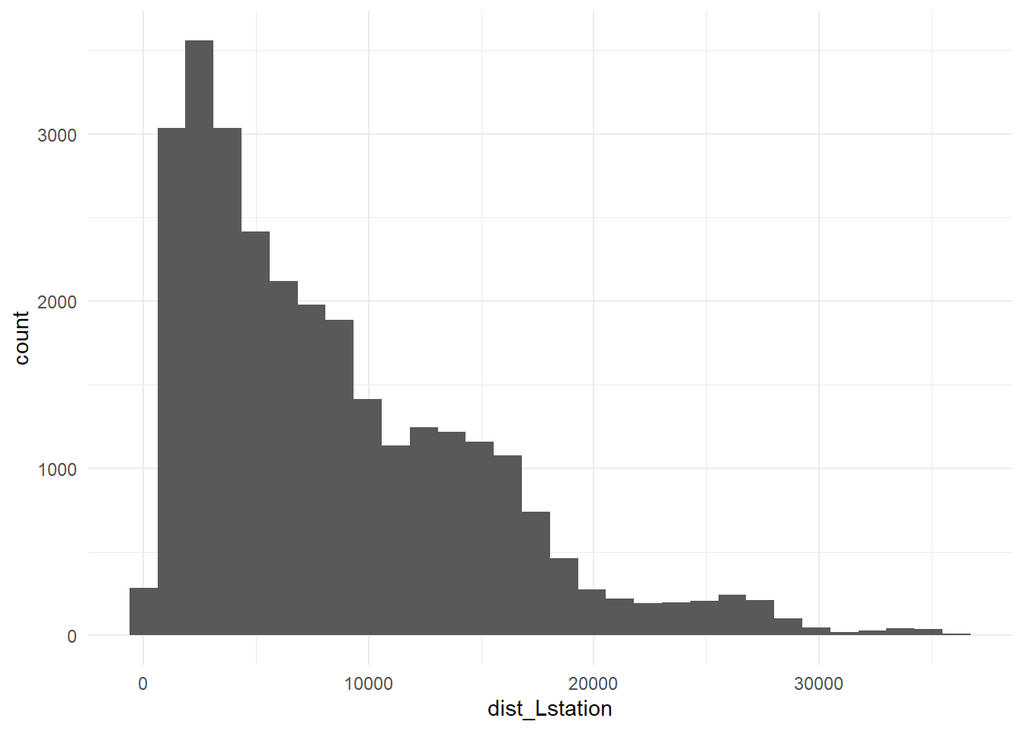

```r
L_stations <- st_read("https://data.cityofchicago.org/resource/3tzw-cg4m.geojson") |>
  st_transform(st_crs(all_sales))
nearest_idx <- st_nearest_feature(all_sales$geometry, L_stations)

all_sales <- all_sales %>%
  mutate(dist_Lstation = as.numeric(
    st_distance(geometry, L_stations[nearest_idx, ], by_element = TRUE)))


ggplot(all_sales, aes(x = dist_Lstation)) + geom_histogram(bins = 30) + theme_minimal()
```

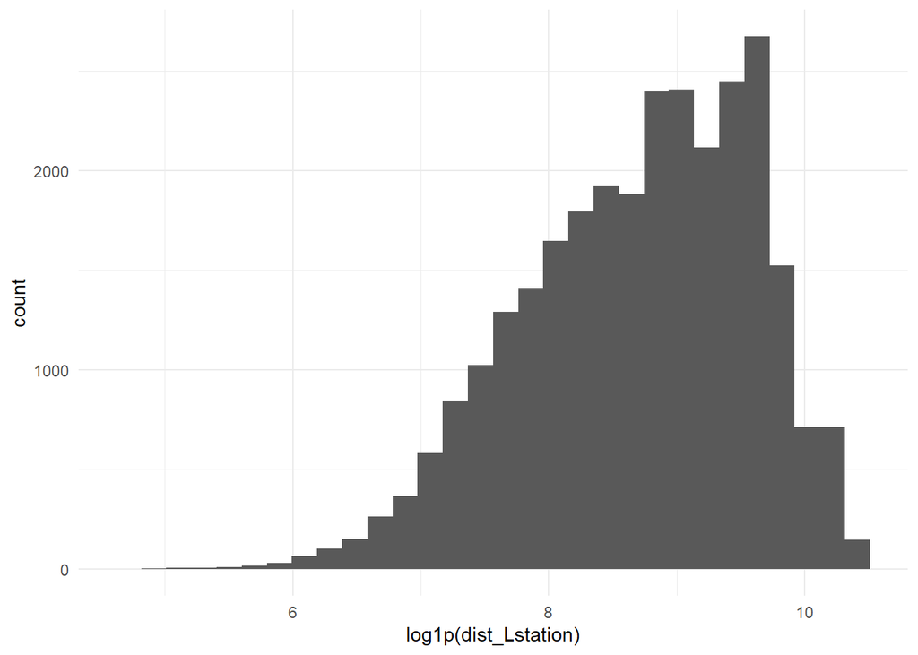

```r
ggplot(all_sales, aes(x = log1p(dist_Lstation))) + geom_histogram(bins = 30) + theme_minimal()
```

```r
train_set <- all_sales %>% filter(split == "train")

f3 <- sale_price ~ I(building_age^2) + building_age + Cat_bedroom_num + Cat_fireplaces_num + building_sf + log_lotsize_sqft + log1p(dist_Lstation)

m3 <- lm(f3, data = train_set)
summary(m3)
```

```
Call:
lm(formula = f3, data = train_set)

Residuals:
     Min       1Q   Median       3Q      Max
-2422094  -138265     -478   123524 20819347

Coefficients:
                                   Estimate  Std. Error t value
(Intercept)                      596972.783   50272.600  11.875
I(building_age^2)                    36.476       2.100  17.373
building_age                      -7265.979     343.524 -21.151
Cat_bedroom_num3 bedrooms       -102990.980    5694.349 -18.087
Cat_bedroom_num4-5 bedrooms     -160311.881    8047.014 -19.922
Cat_bedroom_num6+ bedrooms        -7255.809   21715.700  -0.334
Cat_fireplaces_num1 fireplace     25241.368    7321.316   3.448
Cat_fireplaces_num2+ fireplaces  363045.956   13655.950  26.585
building_sf                         473.676       5.161  91.772
log_lotsize_sqft                  17989.408    6622.278   2.716
log1p(dist_Lstation)             -71171.725    2984.757 -23.845
                                            Pr(>|t|)
(Intercept)                     < 0.0000000000000002 ***
I(building_age^2)               < 0.0000000000000002 ***
building_age                    < 0.0000000000000002 ***
Cat_bedroom_num3 bedrooms       < 0.0000000000000002 ***
Cat_bedroom_num4-5 bedrooms     < 0.0000000000000002 ***
Cat_bedroom_num6+ bedrooms                  0.738287
Cat_fireplaces_num1 fireplace               0.000566 ***
Cat_fireplaces_num2+ fireplaces < 0.0000000000000002 ***
building_sf                     < 0.0000000000000002 ***
log_lotsize_sqft                            0.006603 **
log1p(dist_Lstation)            < 0.0000000000000002 ***
---
Signif. codes:  0 '***' 0.001 '**' 0.01 '*' 0.05 '.' 0.1 ' ' 1

Residual standard error: 340800 on 22840 degrees of freedom
Multiple R-squared:  0.5904,    Adjusted R-squared:  0.5902
F-statistic:  3292 on 10 and 22840 DF,  p-value: < 0.00000000000000022
```

```r
train_set$resid_m3 <- residuals(m3)

mc <- moran.mc(train_set$resid_m3, w_knn, nsim = 499)
mc$statistic
```

```
statistic
0.3352499
```

```r
mc$p.value
```

```
[1] 0.002
```

```r
model_log <- model_log %>%
  add_row(model = "m3", added = "Station distance",
          cv_rmse = cv_rmse(f3, train_set),
          morans_i = mc$statistic,
          moran_p = mc$p.value,
          notes = "Proximity to L metro, logged")

model_log
```

```
# A tibble: 3 × 6
  model added                cv_rmse morans_i moran_p notes
  <chr> <chr>                  <dbl>    <dbl>   <dbl> <chr>
1 m1    Baseline             349355.    0.356   0.002 Squared building age, bui…
2 m2    Transformed Baseline 335668.    0.331   0.002 transformed baseline
3 m3    Station distance     331202.    0.335   0.002 Proximity to L metro, log…
```

### Outdoor seating

We then added proximity to outdoor seating. We assumed that proximity to outdoor seating may affect housing prices because it reflects the types of businesses that are nearby.

```r
outdoor_seat <- st_read("https://data.cityofchicago.org/api/v3/views/qnjv-hj2q/query.geojson") |>
  st_transform(st_crs(all_sales))
nearest_idx <- st_nearest_feature(all_sales$geometry, outdoor_seat)

all_sales <- all_sales %>%
  mutate(dist_cafe_seat = as.numeric(
    st_distance(geometry, outdoor_seat[nearest_idx, ], by_element = TRUE)))

train_set <- all_sales %>% filter(split == "train")

f4 <- sale_price ~ I(building_age^2) + building_age + Cat_bedroom_num + Cat_fireplaces_num + building_sf + log_lotsize_sqft + log1p(dist_Lstation) + dist_cafe_seat

m4 <- lm(f4, data = train_set)
summary(m4)
```

```
Call:
lm(formula = f4, data = train_set)

Residuals:
     Min       1Q   Median       3Q      Max
-2274548  -123715    -1400   110313 20817863

Coefficients:
                                    Estimate   Std. Error t value
(Intercept)                      319187.1693   49645.3680   6.429
I(building_age^2)                    32.1290       2.0501  15.672
building_age                      -6637.1746     335.2953 -19.795
Cat_bedroom_num3 bedrooms        -97177.5241    5552.3551 -17.502
Cat_bedroom_num4-5 bedrooms     -155509.3626    7844.0058 -19.825
Cat_bedroom_num6+ bedrooms        18585.6371   21177.6488   0.878
Cat_fireplaces_num1 fireplace     16703.6864    7139.7408   2.340
Cat_fireplaces_num2+ fireplaces  359205.1094   13309.8317  26.988
building_sf                         447.3945       5.0870  87.948
log_lotsize_sqft                  42901.5462    6493.9528   6.606
log1p(dist_Lstation)             -50292.5853    2970.4864 -16.931
dist_cafe_seat                      -12.5745       0.3621 -34.728
                                            Pr(>|t|)
(Intercept)                          0.0000000001307 ***
I(building_age^2)               < 0.0000000000000002 ***
building_age                    < 0.0000000000000002 ***
Cat_bedroom_num3 bedrooms       < 0.0000000000000002 ***
Cat_bedroom_num4-5 bedrooms     < 0.0000000000000002 ***
Cat_bedroom_num6+ bedrooms                    0.3802
Cat_fireplaces_num1 fireplace                 0.0193 *
Cat_fireplaces_num2+ fireplaces < 0.0000000000000002 ***
building_sf                     < 0.0000000000000002 ***
log_lotsize_sqft                     0.0000000000402 ***
log1p(dist_Lstation)            < 0.0000000000000002 ***
dist_cafe_seat                  < 0.0000000000000002 ***
---
Signif. codes:  0 '***' 0.001 '**' 0.01 '*' 0.05 '.' 0.1 ' ' 1

Residual standard error: 332200 on 22839 degrees of freedom
Multiple R-squared:  0.611, Adjusted R-squared:  0.6108
F-statistic:  3261 on 11 and 22839 DF,  p-value: < 0.00000000000000022
```

```r
train_set$resid_m4 <- residuals(m4)

mc <- moran.mc(train_set$resid_m4, w_knn, nsim = 499)
mc$statistic
```

```
statistic
0.3203057
```

```r
mc$p.value
```

```
[1] 0.002
```

```r
model_log <- model_log %>%
  add_row(model = "m4", added = "Distance to outdoor seating",
          cv_rmse = cv_rmse(f4, train_set),
          morans_i = mc$statistic,
          moran_p = mc$p.value,
          notes = "+ cafe seat")

model_log
```

```
# A tibble: 4 × 6
  model added                       cv_rmse morans_i moran_p notes
  <chr> <chr>                         <dbl>    <dbl>   <dbl> <chr>
1 m1    Baseline                    349355.    0.356   0.002 Squared building a…
2 m2    Transformed Baseline        335668.    0.331   0.002 transformed baseli…
3 m3    Station distance            331202.    0.335   0.002 Proximity to L met…
4 m4    Distance to outdoor seating 321980.    0.320   0.002 + cafe seat
```

### Bus stops

Bus is another common type of public transit in Chicago, and we assumed that the closer to the bus stop, the better accessibility a household may have.

Because the bus stops are dense and people may use different bus stop for different route, we calculate the average distance to 5 closest bus stops.

```r
crs_projected <- 3435
bus_stops <- st_read(
  "https://data.cityofchicago.org/api/v3/views/qs84-j7wh/query.geojson?accessType=DOWNLOAD",
  quiet = TRUE
) %>%
  st_transform(crs_projected) %>%
  filter(!st_is_empty(geometry))

all_sales <- all_sales %>%
  st_transform(crs_projected)

bus_knn <- st_nn(
  all_sales,
  bus_stops,
  k = 5,
  returnDist = TRUE,
  progress = FALSE
)

all_sales$bus_knn5 <- sapply(
  bus_knn$dist,
  mean
)

train_set <- all_sales %>% filter(split == "train")

f5 <- sale_price ~ I(building_age^2) + building_age + Cat_bedroom_num + Cat_fireplaces_num + building_sf + log_lotsize_sqft + log1p(dist_Lstation) + dist_cafe_seat + bus_knn5

m5 <- lm(f5, data = train_set)
summary(m5)
```

```
Call:
lm(formula = f5, data = train_set)

Residuals:
     Min       1Q   Median       3Q      Max
-2276427  -123480     -917   110231 20818492

Coefficients:
                                    Estimate   Std. Error t value
(Intercept)                      332905.0252   49975.9086   6.661
I(building_age^2)                    32.4945       2.0557  15.807
building_age                      -6677.2162     335.6858 -19.891
Cat_bedroom_num3 bedrooms        -97301.9310    5552.0401 -17.525
Cat_bedroom_num4-5 bedrooms     -155626.0924    7843.3652 -19.842
Cat_bedroom_num6+ bedrooms        18276.5586   21175.9035   0.863
Cat_fireplaces_num1 fireplace     16280.7524    7141.2424   2.280
Cat_fireplaces_num2+ fireplaces  358867.6392   13309.2430  26.964
building_sf                         447.4670       5.0866  87.970
log_lotsize_sqft                  40987.8987    6543.1953   6.264
log1p(dist_Lstation)             -51023.0214    2986.0977 -17.087
dist_cafe_seat                      -12.6078       0.3623 -34.797
bus_knn5                             10.4587       4.4081   2.373
                                            Pr(>|t|)
(Intercept)                          0.0000000000278 ***
I(building_age^2)               < 0.0000000000000002 ***
building_age                    < 0.0000000000000002 ***
Cat_bedroom_num3 bedrooms       < 0.0000000000000002 ***
Cat_bedroom_num4-5 bedrooms     < 0.0000000000000002 ***
Cat_bedroom_num6+ bedrooms                    0.3881
Cat_fireplaces_num1 fireplace                 0.0226 *
Cat_fireplaces_num2+ fireplaces < 0.0000000000000002 ***
building_sf                     < 0.0000000000000002 ***
log_lotsize_sqft                     0.0000000003814 ***
log1p(dist_Lstation)            < 0.0000000000000002 ***
dist_cafe_seat                  < 0.0000000000000002 ***
bus_knn5                                      0.0177 *
---
Signif. codes:  0 '***' 0.001 '**' 0.01 '*' 0.05 '.' 0.1 ' ' 1

Residual standard error: 332100 on 22838 degrees of freedom
Multiple R-squared:  0.611, Adjusted R-squared:  0.6108
F-statistic:  2990 on 12 and 22838 DF,  p-value: < 0.00000000000000022
```

```r
train_set$resid_m5 <- residuals(m5)

mc <- moran.mc(train_set$resid_m5, w_knn, nsim = 499)
mc$statistic
```

```
statistic
0.3202168
```

```r
mc$p.value
```

```
[1] 0.002
```

```r
model_log <- model_log %>%
  add_row(model = "m5", added = "Bus Stops",
          cv_rmse = cv_rmse(f5, train_set),
          morans_i = mc$statistic,
          moran_p = mc$p.value,
          notes = "+ bus knn5")

model_log
```

```
# A tibble: 5 × 6
  model added                       cv_rmse morans_i moran_p notes
  <chr> <chr>                         <dbl>    <dbl>   <dbl> <chr>
1 m1    Baseline                    349355.    0.356   0.002 Squared building a…
2 m2    Transformed Baseline        335668.    0.331   0.002 transformed baseli…
3 m3    Station distance            331202.    0.335   0.002 Proximity to L met…
4 m4    Distance to outdoor seating 321980.    0.320   0.002 + cafe seat
5 m5    Bus Stops                   321942.    0.320   0.002 + bus knn5
```

### Crime

We also looked at the social risks surrounding a house. Crime is an important indicator. We thought that all types of crime reduce the perception of safety in an area. Therefore, we decided to include all crimes in 2022-2023. We selected all the crime data from 2022 to 2023 and counted how many of them happened within 500 feet of a house.

```r
crime_2022 <- read.csv("assignments/assignment5_files/crime_2022.csv")

crime_2022 <- crime_2022 %>%
  mutate(
    latitude = as.numeric(latitude),
    longitude = as.numeric(longitude)
  ) %>%
  filter(
    !is.na(latitude),
    !is.na(longitude)
  )

crime_sf <- st_as_sf(
  crime_2022,
  coords = c("longitude", "latitude"),
  crs = 4326
)

crs_projected <- 3435

crime_sf <- st_transform(crime_sf, crs_projected)


sales_buffer <- st_buffer(all_sales, 500)

crime_hits <- st_intersects(sales_buffer, crime_sf)

all_sales <- all_sales |>
  mutate(crime_count_500feet = lengths(crime_hits))

summary(all_sales$crime_count_500feet)
```

```
   Min. 1st Qu.  Median    Mean 3rd Qu.    Max.
   0.00   11.00   22.00   27.98   37.00  438.00
```

```r
train_set <- all_sales %>% filter(split == "train")

f6 <- sale_price ~ I(building_age^2) + building_age + Cat_bedroom_num + Cat_fireplaces_num + building_sf + log_lotsize_sqft + log1p(dist_Lstation) +  crime_count_500feet

m6 <- lm(f6, data = train_set)
summary(m6)
```

```
Call:
lm(formula = f6, data = train_set)

Residuals:
     Min       1Q   Median       3Q      Max
-2370206  -130266      424   115742 20793244

Coefficients:
                                   Estimate  Std. Error t value
(Intercept)                      992842.728   52290.485  18.987
I(building_age^2)                    40.647       2.081  19.536
building_age                      -7543.413     339.437 -22.223
Cat_bedroom_num3 bedrooms       -101283.250    5623.805 -18.010
Cat_bedroom_num4-5 bedrooms     -161475.306    7946.839 -20.319
Cat_bedroom_num6+ bedrooms         1255.368   21447.879   0.059
Cat_fireplaces_num1 fireplace     21888.742    7231.380   3.027
Cat_fireplaces_num2+ fireplaces  357508.723   13487.659  26.506
building_sf                         472.679       5.097  92.732
log_lotsize_sqft                 -12025.205    6657.150  -1.806
log1p(dist_Lstation)             -81026.223    2975.749 -27.229
crime_count_500feet               -2378.116      98.634 -24.110
                                            Pr(>|t|)
(Intercept)                     < 0.0000000000000002 ***
I(building_age^2)               < 0.0000000000000002 ***
building_age                    < 0.0000000000000002 ***
Cat_bedroom_num3 bedrooms       < 0.0000000000000002 ***
Cat_bedroom_num4-5 bedrooms     < 0.0000000000000002 ***
Cat_bedroom_num6+ bedrooms                   0.95333
Cat_fireplaces_num1 fireplace                0.00247 **
Cat_fireplaces_num2+ fireplaces < 0.0000000000000002 ***
building_sf                     < 0.0000000000000002 ***
log_lotsize_sqft                             0.07088 .
log1p(dist_Lstation)            < 0.0000000000000002 ***
crime_count_500feet             < 0.0000000000000002 ***
---
Signif. codes:  0 '***' 0.001 '**' 0.01 '*' 0.05 '.' 0.1 ' ' 1

Residual standard error: 336600 on 22839 degrees of freedom
Multiple R-squared:  0.6006,    Adjusted R-squared:  0.6004
F-statistic:  3122 on 11 and 22839 DF,  p-value: < 0.00000000000000022
```

```r
train_set$resid_m6 <- residuals(m6)

mc <- moran.mc(train_set$resid_m6, w_knn, nsim = 499)
mc$statistic
```

```
statistic
0.3146674
```

```r
mc$p.value
```

```
[1] 0.002
```

```r
model_log <- model_log %>%
  add_row(model = "m6", added = "Crime",
          cv_rmse = cv_rmse(f6, train_set),
          morans_i = mc$statistic,
          moran_p = mc$p.value,
          notes = "+ crime")

model_log
```

```
# A tibble: 6 × 6
  model added                       cv_rmse morans_i moran_p notes
  <chr> <chr>                         <dbl>    <dbl>   <dbl> <chr>
1 m1    Baseline                    349355.    0.356   0.002 Squared building a…
2 m2    Transformed Baseline        335668.    0.331   0.002 transformed baseli…
3 m3    Station distance            331202.    0.335   0.002 Proximity to L met…
4 m4    Distance to outdoor seating 321980.    0.320   0.002 + cafe seat
5 m5    Bus Stops                   321942.    0.320   0.002 + bus knn5
6 m6    Crime                       326738.    0.315   0.002 + crime
```

The result of our crime model shows that it may have a significant impact on our model. The CV-RMSE for the Crime model is $326,738, and Moran’s I is 0.315. Although RMSE did not improve from the last model, Moran’s I did.

### Median income

The characteristics of the surrounding neighborhood may also influence home sale prices. To capture this neighborhood-level effect, we first incorporated the median household income of the census tract in which each property was located.

```r
tract_income <- get_acs(
  geography = "tract",
  variables = c(neighborhood_income = "B19013_001"),
  state = "IL",
  county = "Cook",
  year = 2022,
  survey = "acs5",
  geometry = TRUE
)
tract_income <- tract_income %>%
  select(GEOID, NAME, neighborhood_income = estimate, geometry)

tract_income <- st_transform(tract_income, crs_projected)

income_join <- st_join(
  all_sales,
  tract_income %>%
    select(neighborhood_income),
  join = st_within,
  left = TRUE
)

all_sales$neighborhood_income <- income_join$neighborhood_income

model_data <- median(all_sales$neighborhood_income[all_sales$split == "train"], na.rm = TRUE)

all_sales <- all_sales %>% mutate(neighborhood_income = replace_na(neighborhood_income, model_data))


train_set <- all_sales %>% filter(split == "train")

f7 <- sale_price ~ I(building_age^2) + building_age + Cat_bedroom_num + Cat_fireplaces_num + building_sf + log_lotsize_sqft + log1p(dist_Lstation) + crime_count_500feet + neighborhood_income

m7 <- lm(f7, data = train_set)
summary(m7)

train_set$resid_m7 <- residuals(m7)

mc <- moran.mc(train_set$resid_m7, w_knn, nsim = 499)
mc$statistic
mc$p.value

model_log <- model_log %>%
  add_row(model = "m7", added = "Income",
          cv_rmse = cv_rmse(f7, train_set),
          morans_i = mc$statistic,
          moran_p = mc$p.value,
          notes = "+ tract income")

model_log
```

[output not shown]

The result of our tract level medium household income model shows that it has a significant impact on our model. The CV-RMSE for the Income model is $306,497, and Moran’s I is 0.289. Both indicators improved from the last model.

### Education and Elderly

We assumed some neighborhood demographic information may impact house value. We looked at whether the educational attainment of the population and the percentage of elderly people impacted house price. We assumed that a higher share of people with Bachelor’s degrees, as well as a higher share of elderly in a tract’s population could make a given house more valuable.

```r
vars <- load_variables(2022, "acs5")

chicago_tracts <- get_acs(
  geography = "tract",
  state = "IL",
  county = "Cook",
  variables = c(                 # universe #
    total_pop = "B01003_001",    # people
    totalHH = "B08201_001",      # households
    #medinc = "B07011_001",       # people
    under18 = "C18108_002",      # people
    adult_18_64 = "C18108_006",  # people
    over65 = "C18108_010",      # people
    edu_total  = "B15003_001",   # people >25yrs
    ba         = "B15003_022",   # people >25yrs
    ma         = "B15003_023",   # people >25yrs
    prof       = "B15003_024",   # people >25yrs
    phd        = "B15003_025"    # people >25yrs
  ),
    year = 2022,
  output = "wide",
  geometry = TRUE
) %>%
  st_transform(3435)

#Transform
chicago_tracts <- chicago_tracts %>%
  mutate(
    pct_18to64 = adult_18_64E / total_popE * 100,
    pct_under18 = under18E / total_popE * 100,
    pct_over64 = over65E / total_popE * 100,
    pct_ba     = (baE + maE + profE + phdE) / edu_totalE * 100
    ) %>%
  mutate(pct_over64 = replace_na(pct_over64, 0),
         pct_ba     = replace_na(pct_ba, 0))


#Spatially Join Demographic Data
all_sales <- st_join(
  all_sales,
  chicago_tracts,
  join = st_within,
  left = TRUE
)

#Replace NAs
over64_NA <- median(all_sales$pct_over64[all_sales$split == "train"], na.rm = TRUE)

all_sales <- all_sales %>% mutate(pct_over64 = replace_na(pct_over64, over64_NA))

BA_NA <- median(all_sales$pct_ba[all_sales$split == "train"], na.rm = TRUE)

all_sales <- all_sales %>% mutate(pct_ba = replace_na(pct_ba, BA_NA))

ggplot(all_sales, aes(x = pct_ba, y = sale_price)) +
  geom_point(alpha = 0.5) +
  geom_smooth(
    method = "lm",
    formula = y ~ x + I(x^2),
    se = TRUE,
    color = "red"
  ) +
  labs(
    title = "Sale Price vs. Percentage of BA",
    x = "Bachelors Degree (%)",
    y = "Sale Price ($)"
  ) +
  theme_minimal()
```

[output not shown]

```r
train_set <- all_sales %>% filter(split == "train")

f8 <- sale_price ~ I(building_age^2) + building_age + Cat_bedroom_num + Cat_fireplaces_num + building_sf + log_lotsize_sqft + log1p(dist_Lstation) + crime_count_500feet + neighborhood_income + pct_over64 + pct_ba + I(pct_ba^2)

m8 <- lm(f8, data = train_set)
summary(m8)

train_set$resid_m8 <- residuals(m8)

mc <- moran.mc(train_set$resid_m8, w_knn, nsim = 499)
mc$statistic
mc$p.value


model_log <- model_log %>%
  add_row(model = "m8", added = "Demographics",
          cv_rmse = cv_rmse(f8, train_set),
          morans_i = mc$statistic,
          moran_p = mc$p.value,
          notes = "+ Higher edu, elderly")

model_log
```

[output not shown]

The result of our education and elderly variable additions shows that they have a significant impact on our model. We squared the share of the population that has a bachelor’s degree because of the curved distribution. The CV-RMSE for the Demographics model is $295,286, and Moran’s I is 0.267. Both indicators improved from the last model.

### Grocery

We also wanted to look at the impact of amenities. Instead of looking at all possible amenities, we decided to only look at groceries, as that is an amenity that people need to use on a very regular basis. We assumed that the more open grocery stores near the a house, the more convenient the house location was, and therefore the more valuable the property.

```r
grocery <- st_read(
  "https://data.cityofchicago.org/api/v3/views/3e26-zek2/query.geojson",
  quiet = TRUE
) %>%
  st_transform(crs_projected) %>%
  filter(!st_is_empty(geometry))

grocery <- grocery %>%
  filter(new_status == "OPEN")
nearest_idx_G <- st_nearest_feature(all_sales$geometry, grocery)

all_sales <- all_sales %>%
  mutate(dist_grocery = as.numeric(
    st_distance(geometry, grocery[nearest_idx_G , ], by_element = TRUE)))

train_set <- all_sales %>% filter(split == "train")

f9 <- sale_price ~ I(building_age^2) + building_age + Cat_bedroom_num + Cat_fireplaces_num + building_sf + log_lotsize_sqft + log1p(dist_Lstation) + crime_count_500feet + neighborhood_income + pct_over64 + pct_ba + I(pct_ba^2) + dist_grocery

m9 <- lm(f9, data = train_set)
summary(m9)
```

```
Call:
lm(formula = f9, data = train_set)

Residuals:
     Min       1Q   Median       3Q      Max
-1846822  -104680     3312   103080 20731721

Coefficients:
                                    Estimate   Std. Error t value
(Intercept)                     -367080.8252   52412.5097  -7.004
I(building_age^2)                    29.0278       1.9444  14.929
building_age                      -5547.7049     316.1084 -17.550
Cat_bedroom_num3 bedrooms        -85298.7286    5146.9847 -16.573
Cat_bedroom_num4-5 bedrooms     -135160.8128    7282.9484 -18.559
Cat_bedroom_num6+ bedrooms        58078.1513   19590.3315   2.965
Cat_fireplaces_num1 fireplace    -63333.6764    6764.5941  -9.363
Cat_fireplaces_num2+ fireplaces  208529.5637   12552.2557  16.613
building_sf                         368.2082       4.9285  74.710
log_lotsize_sqft                 106141.2944    6406.8603  16.567
log1p(dist_Lstation)             -36575.6784    2884.4760 -12.680
crime_count_500feet                -782.0100     101.6933  -7.690
neighborhood_income                   1.1915       0.1031  11.559
pct_over64                        -3997.9621     369.6144 -10.817
pct_ba                            -6571.3602     400.8011 -16.396
I(pct_ba^2)                         137.7080       4.5967  29.958
dist_grocery                         -8.3956       1.2109  -6.933
                                            Pr(>|t|)
(Intercept)                       0.0000000000025623 ***
I(building_age^2)               < 0.0000000000000002 ***
building_age                    < 0.0000000000000002 ***
Cat_bedroom_num3 bedrooms       < 0.0000000000000002 ***
Cat_bedroom_num4-5 bedrooms     < 0.0000000000000002 ***
Cat_bedroom_num6+ bedrooms                   0.00303 **
Cat_fireplaces_num1 fireplace   < 0.0000000000000002 ***
Cat_fireplaces_num2+ fireplaces < 0.0000000000000002 ***
building_sf                     < 0.0000000000000002 ***
log_lotsize_sqft                < 0.0000000000000002 ***
log1p(dist_Lstation)            < 0.0000000000000002 ***
crime_count_500feet               0.0000000000000153 ***
neighborhood_income             < 0.0000000000000002 ***
pct_over64                      < 0.0000000000000002 ***
pct_ba                          < 0.0000000000000002 ***
I(pct_ba^2)                     < 0.0000000000000002 ***
dist_grocery                      0.0000000000042157 ***
---
Signif. codes:  0 '***' 0.001 '**' 0.01 '*' 0.05 '.' 0.1 ' ' 1

Residual standard error: 307100 on 22834 degrees of freedom
Multiple R-squared:  0.6676,    Adjusted R-squared:  0.6673
F-statistic:  2866 on 16 and 22834 DF,  p-value: < 0.00000000000000022
```

```r
train_set$resid_m9 <- residuals(m9)

mc <- moran.mc(train_set$resid_m9, w_knn, nsim = 499)
mc$statistic
```

```
statistic
0.2661302
```

```r
mc$p.value
```

```
[1] 0.002
```

```r
model_log <- model_log %>%
  add_row(model = "m9", added = "Grocery",
          cv_rmse = cv_rmse(f9, train_set),
          morans_i = mc$statistic,
          moran_p = mc$p.value,
          notes = "+ Grocery")

model_log
```

```
# A tibble: 9 × 6
  model added                       cv_rmse morans_i moran_p notes
  <chr> <chr>                         <dbl>    <dbl>   <dbl> <chr>
1 m1    Baseline                    349355.    0.356   0.002 Squared building a…
2 m2    Transformed Baseline        335668.    0.331   0.002 transformed baseli…
3 m3    Station distance            331202.    0.335   0.002 Proximity to L met…
4 m4    Distance to outdoor seating 321980.    0.320   0.002 + cafe seat
5 m5    Bus Stops                   321942.    0.320   0.002 + bus knn5
6 m6    Crime                       326738.    0.315   0.002 + crime
7 m7    Income                      306497.    0.289   0.002 + tract income
8 m8    Demographics                295286.    0.267   0.002 + Higher edu, elde…
9 m9    Grocery                     294933.    0.266   0.002 + Grocery
```

The result of our grocery model shows that all variables we used have a significant impact on our model. The CV-RMSE for the Grocery model is $294,933, and Moran’s I is 0.266. Both indicator improved from the last model.

### Distance to CBD

Downtown Chicago has many shopping and dining locations, and it attracted many visitors. We wanted to check whether the distance to the CBD area affected housing price also.

```r
cbd <- st_read("https://data.cityofchicago.org/api/v3/views/fe34-kcci/query.geojson?accessType=DOWNLOAD") %>%
  st_as_sf(wkt = "the_geom", crs = 4326) %>%
  st_transform(3435)            # Illinois East State Plane, feet
cbd_pt <- st_centroid(st_geometry(cbd))

all_sales <- all_sales %>%
  mutate(dist_cbd = as.numeric(st_distance(st_geometry(.), cbd_pt)))

train_set <- all_sales %>% filter(split == "train")

f10 <- sale_price ~ I(building_age^2) + building_age + Cat_bedroom_num + Cat_fireplaces_num + building_sf + log_lotsize_sqft + log1p(dist_Lstation) + crime_count_500feet + neighborhood_income + pct_over64 + pct_ba + I(pct_ba^2) + dist_grocery + dist_cbd

m10 <- lm(f10, data = train_set)
summary(m10)
```

```
Call:
lm(formula = f10, data = train_set)

Residuals:
     Min       1Q   Median       3Q      Max
-1734083  -102966     5132   101683 20695575

Coefficients:
                                    Estimate   Std. Error t value
(Intercept)                     -756559.0125   56736.1814 -13.335
I(building_age^2)                    22.2447       1.9712  11.285
building_age                      -4603.6608     318.7753 -14.442
Cat_bedroom_num3 bedrooms        -83584.6828    5114.6833 -16.342
Cat_bedroom_num4-5 bedrooms     -130130.6071    7241.7278 -17.970
Cat_bedroom_num6+ bedrooms        68176.4170   19472.4890   3.501
Cat_fireplaces_num1 fireplace    -64071.7483    6721.0139  -9.533
Cat_fireplaces_num2+ fireplaces  208460.9517   12471.1381  16.715
building_sf                         355.8103       4.9489  71.897
log_lotsize_sqft                 137366.4726    6616.6310  20.761
log1p(dist_Lstation)              -6522.8034    3351.6470  -1.946
crime_count_500feet                -922.7233     101.3633  -9.103
neighborhood_income                   1.0365       0.1028  10.082
pct_over64                        -2880.9660     372.8638  -7.727
pct_ba                            -5544.1570     402.6174 -13.770
I(pct_ba^2)                         127.0607       4.6083  27.572
dist_grocery                         -2.5742       1.2493  -2.061
dist_cbd                             -3.7708       0.2181 -17.292
                                            Pr(>|t|)
(Intercept)                     < 0.0000000000000002 ***
I(building_age^2)               < 0.0000000000000002 ***
building_age                    < 0.0000000000000002 ***
Cat_bedroom_num3 bedrooms       < 0.0000000000000002 ***
Cat_bedroom_num4-5 bedrooms     < 0.0000000000000002 ***
Cat_bedroom_num6+ bedrooms                  0.000464 ***
Cat_fireplaces_num1 fireplace   < 0.0000000000000002 ***
Cat_fireplaces_num2+ fireplaces < 0.0000000000000002 ***
building_sf                     < 0.0000000000000002 ***
log_lotsize_sqft                < 0.0000000000000002 ***
log1p(dist_Lstation)                        0.051649 .
crime_count_500feet             < 0.0000000000000002 ***
neighborhood_income             < 0.0000000000000002 ***
pct_over64                        0.0000000000000115 ***
pct_ba                          < 0.0000000000000002 ***
I(pct_ba^2)                     < 0.0000000000000002 ***
dist_grocery                                0.039355 *
dist_cbd                        < 0.0000000000000002 ***
---
Signif. codes:  0 '***' 0.001 '**' 0.01 '*' 0.05 '.' 0.1 ' ' 1

Residual standard error: 305100 on 22833 degrees of freedom
Multiple R-squared:  0.6719,    Adjusted R-squared:  0.6716
F-statistic:  2750 on 17 and 22833 DF,  p-value: < 0.00000000000000022
```

```r
train_set$resid_m10 <- residuals(m10)

mc <- moran.mc(train_set$resid_m10, w_knn, nsim = 499)
mc$statistic
```

```
statistic
0.2609112
```

```r
mc$p.value
```

```
[1] 0.002
```

```r
model_log <- model_log %>%
  add_row(model = "m10", added = "Distance to CBD",
          cv_rmse = cv_rmse(f10, train_set),
          morans_i = mc$statistic,
          moran_p = mc$p.value,
          notes = "+ Distance to CBD")

model_log
```

```
# A tibble: 10 × 6
   model added                       cv_rmse morans_i moran_p notes
   <chr> <chr>                         <dbl>    <dbl>   <dbl> <chr>
 1 m1    Baseline                    349355.    0.356   0.002 Squared building …
 2 m2    Transformed Baseline        335668.    0.331   0.002 transformed basel…
 3 m3    Station distance            331202.    0.335   0.002 Proximity to L me…
 4 m4    Distance to outdoor seating 321980.    0.320   0.002 + cafe seat
 5 m5    Bus Stops                   321942.    0.320   0.002 + bus knn5
 6 m6    Crime                       326738.    0.315   0.002 + crime
 7 m7    Income                      306497.    0.289   0.002 + tract income
 8 m8    Demographics                295286.    0.267   0.002 + Higher edu, eld…
 9 m9    Grocery                     294933.    0.266   0.002 + Grocery
10 m10   Distance to CBD             292870.    0.261   0.002 + Distance to CBD
```

The CV-RMSE for the Distance to CBD model is $292,870, and Moran’s I is 0.261.

### Community

Our last variable is a fixed effect that accounts for differences between neighborhoods that cannot be explicitly identified. These differences may include unjustifiable factors like social infrastructure, kinship, and community identity. It may also include the sanitary condition, vacancy, greenery, or other physical factors.

```r
community <- st_read(
  "https://data.cityofchicago.org/resource/y6yq-dbs2.geojson"
)
community <- st_transform(community, crs_projected)


sales_community <- st_join(
  all_sales,
  community,
  join = st_within,
  left = TRUE
)

all_sales$community <- sales_community$pri_neigh

all_sales$community[all_sales$community == "Boystown"] <- "Unknown"

all_sales$community <- factor(replace_na(as.character(all_sales$community), "Unknown"))


all_sales %>%
  st_drop_geometry() %>%
  group_by(community) %>%
  summarise(n = n())
```

```
# A tibble: 90 × 2
   community          n
   <fct>          <int>
 1 Albany Park      323
 2 Andersonville     37
 3 Archer Heights   126
 4 Armour Square     20
 5 Ashburn          945
 6 Auburn Gresham   950
 7 Austin           762
 8 Avalon Park      315
 9 Avondale         270
10 Belmont Cragin   548
# ℹ 80 more rows
```

```r
train_set <- all_sales %>% filter(split == "train")

f11 <- sale_price ~ I(building_age^2) + building_age + Cat_bedroom_num + Cat_fireplaces_num + building_sf + log_lotsize_sqft + crime_count_500feet + neighborhood_income + pct_over64 + pct_ba + I(pct_ba^2)  + dist_cbd + community

m11 <- lm(f11, data = train_set)
summary(m11)
```

```
Call:
lm(formula = f11, data = train_set)

Residuals:
     Min       1Q   Median       3Q      Max
-1548515   -87119     3539    89936 20840384

Coefficients:
                                     Estimate    Std. Error t value
(Intercept)                     -1041725.3390    61265.3615 -17.003
I(building_age^2)                     27.3619        2.0342  13.451
building_age                       -5433.8195      327.5670 -16.588
Cat_bedroom_num3 bedrooms         -73061.3775     4857.2418 -15.042
Cat_bedroom_num4-5 bedrooms      -107023.3040     6897.4410 -15.516
Cat_bedroom_num6+ bedrooms         96281.7403    18414.4413   5.229
Cat_fireplaces_num1 fireplace     -49976.4445     6434.3385  -7.767
Cat_fireplaces_num2+ fireplaces   175382.7574    11891.6678  14.748
building_sf                          316.2948        4.8248  65.556
log_lotsize_sqft                  181484.6150     6615.6789  27.433
crime_count_500feet                 -405.4235      108.4380  -3.739
neighborhood_income                   -0.1994        0.1285  -1.552
pct_over64                           122.1470      448.4533   0.272
pct_ba                             -1628.6352      631.5321  -2.579
I(pct_ba^2)                           56.0177        7.1495   7.835
dist_cbd                              -3.4083        0.6488  -5.253
communityAndersonville            300616.5097    56634.0744   5.308
communityArcher Heights          -116051.8519    34834.6969  -3.332
communityArmour Square           -101566.1756    78265.3587  -1.298
communityAshburn                 -114055.6521    24447.8533  -4.665
communityAuburn Gresham          -181717.6261    23861.8591  -7.615
communityAustin                  -233949.2098    23906.7792  -9.786
communityAvalon Park             -183345.6221    27807.0621  -6.593
communityAvondale                  52750.2746    27792.7972   1.898
communityBelmont Cragin           -58640.4810    23884.3989  -2.455
communityBeverly                 -243138.4841    27991.1906  -8.686
communityBridgeport              -125194.0888    30047.7497  -4.167
communityBrighton Park           -128393.0447    30916.4213  -4.153
communityBucktown                 265359.2342    34027.8943   7.798
communityBurnside                -201591.7667    43309.8095  -4.655
communityCalumet Heights         -184666.7305    26979.2265  -6.845
```

[output cut: 171 more lines]

```
communityWest Elsdon                        0.000267 ***
communityWest Lawn                          0.000586 ***
communityWest Loop                          0.327293
communityWest Pullman                       0.000102 ***
communityWest Ridge                         0.025294 *
communityWest Town                          0.000391 ***
communityWicker Park            0.000000000000002238 ***
communityWoodlawn               0.000038761027916471 ***
communityWrigleyville           < 0.0000000000000002 ***
---
Signif. codes:  0 '***' 0.001 '**' 0.01 '*' 0.05 '.' 0.1 ' ' 1

Residual standard error: 285900 on 22746 degrees of freedom
Multiple R-squared:  0.7129,    Adjusted R-squared:  0.7116
F-statistic: 543.2 on 104 and 22746 DF,  p-value: < 0.00000000000000022
```

```r
train_set$resid_m11 <- residuals(m11)

mc <- moran.mc(train_set$resid_m11, w_knn, nsim = 499)
mc$statistic
```

```
statistic
0.1731889
```

```r
mc$p.value
```

```
[1] 0.002
```

```r
model_log <- model_log %>%
  add_row(model = "m11", added = "+ Community",
          cv_rmse = cv_rmse(f11, train_set),
          morans_i = mc$statistic,
          moran_p = mc$p.value,
          notes = " + Community")

model_log
```

```
# A tibble: 11 × 6
   model added                       cv_rmse morans_i moran_p notes
   <chr> <chr>                         <dbl>    <dbl>   <dbl> <chr>
 1 m1    Baseline                    349355.    0.356   0.002 "Squared building…
 2 m2    Transformed Baseline        335668.    0.331   0.002 "transformed base…
 3 m3    Station distance            331202.    0.335   0.002 "Proximity to L m…
 4 m4    Distance to outdoor seating 321980.    0.320   0.002 "+ cafe seat"
 5 m5    Bus Stops                   321942.    0.320   0.002 "+ bus knn5"
 6 m6    Crime                       326738.    0.315   0.002 "+ crime"
 7 m7    Income                      306497.    0.289   0.002 "+ tract income"
 8 m8    Demographics                295286.    0.267   0.002 "+ Higher edu, el…
 9 m9    Grocery                     294933.    0.266   0.002 "+ Grocery"
10 m10   Distance to CBD             292870.    0.261   0.002 "+ Distance to CB…
11 m11   + Community                 273141.    0.173   0.002 " + Community"
```

This will therefore be our final model.

## Part 3: Final model

#### Building character:

- Building size has a strong positive association with sale price: each additional square foot is associated with an estimated $316 increase in price.
- Lot size is also positively associated with sale price.
- Building age has a nonlinear relationship with price, as indicated by the positive squared-age coefficient and negative linear-age coefficient.
- Bedroom count also matters: compared with the house that have 1-2 bedroom, homes with 3 bedrooms and 4–5 bedrooms have lower estimated prices, while homes with 6 or more bedrooms have higher estimated prices.

### Community-level differences:

- Many community fixed-effect coefficients are statistically significant. For example, Lincoln Park, Gold Coast, and Old Town have large positive coefficients relative to the omitted reference community, while several South and West Side communities have negative coefficients.

```r
model_log_final <- model_log  %>%
  distinct(model, .keep_all = TRUE) %>%
  arrange(as.integer(gsub("m", "", model)))

model_log_final
```

```
# A tibble: 11 × 6
   model added                       cv_rmse morans_i moran_p notes
   <chr> <chr>                         <dbl>    <dbl>   <dbl> <chr>
 1 m1    Baseline                    349355.    0.356   0.002 "Squared building…
 2 m2    Transformed Baseline        335668.    0.331   0.002 "transformed base…
 3 m3    Station distance            331202.    0.335   0.002 "Proximity to L m…
 4 m4    Distance to outdoor seating 321980.    0.320   0.002 "+ cafe seat"
 5 m5    Bus Stops                   321942.    0.320   0.002 "+ bus knn5"
 6 m6    Crime                       326738.    0.315   0.002 "+ crime"
 7 m7    Income                      306497.    0.289   0.002 "+ tract income"
 8 m8    Demographics                295286.    0.267   0.002 "+ Higher edu, el…
 9 m9    Grocery                     294933.    0.266   0.002 "+ Grocery"
10 m10   Distance to CBD             292870.    0.261   0.002 "+ Distance to CB…
11 m11   + Community                 273141.    0.173   0.002 " + Community"
```

## Part 4: Where it fails, and who pays

### Residual Map: where do we over predict?

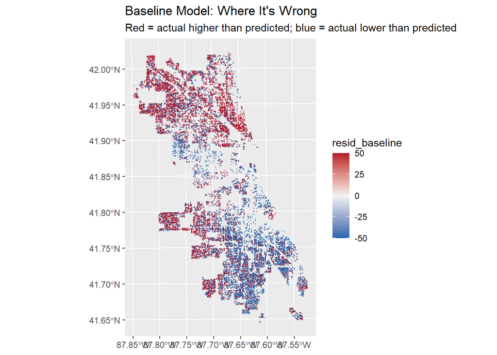

```r
m11 <- lm(
  f11,
  data = st_drop_geometry(train_set),
  na.action = na.fail
)
m1 <- lm(
  f1,
  data = st_drop_geometry(train_set),
  na.action = na.fail
)

train_set <- train_set %>% mutate(resid_final = residuals(m11))
train_set <- train_set %>% mutate(resid_baseline = residuals(m1))

P_baseline <- ggplot(train_set) +
  geom_sf(aes(color = resid_baseline), alpha = 0.7, size = 0.2) +
  scale_color_gradient2(
    low = "#2166ac",
    mid = "grey95",
    high = "#b2182b",
    midpoint = 0,
    limits = c(-50, 50),
    oob = scales::squish
  )  +
  labs(
    title = "Baseline Model: Where It's Wrong",
    subtitle = "Red = actual higher than predicted; blue = actual lower than predicted",
    fill = "Residual"
  )

p_final <- ggplot(train_set) +
  geom_sf(aes(color = resid_final), alpha = 0.7, size = 0.2) +
  scale_color_gradient2(
    low = "#2166ac",
    mid = "grey95",
    high = "#b2182b",
    midpoint = 0,
    limits = c(-50, 50),
    oob = scales::squish
  )  +
  labs(
    title = "Final Model: Where It's Wrong",
    subtitle = "Red = actual higher than predicted; blue = actual lower than predicted",
    fill = "Residual"
  )

P_baseline
```

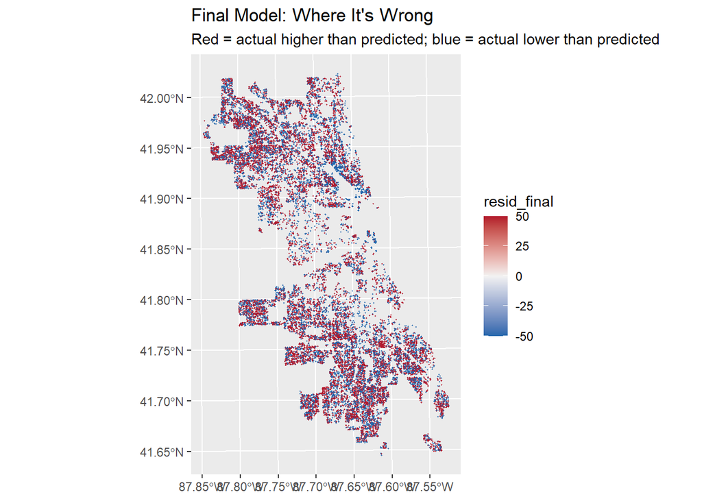

```r
p_final
```

Compared with the baseline model, which tends to underpredict home prices on the North Side and over predict them on the South Side, the final model exhibits weaker spatial autocorrelation in its residuals. No clearly defined area is consistently experiencing over prediction.

### The Tax Divide

Although the residual map does not reveal a clear spatial pattern, we further examined whether prediction errors were associated with sale prices (low v. high prices). Specifically, we investigated whether lower-priced homes were more likely to be over-predicted, which could explain a systematic bias of the model. Assessors judge their work with the ratio of predicted value to sale price, so our analysis included this ratio to help answer this point.

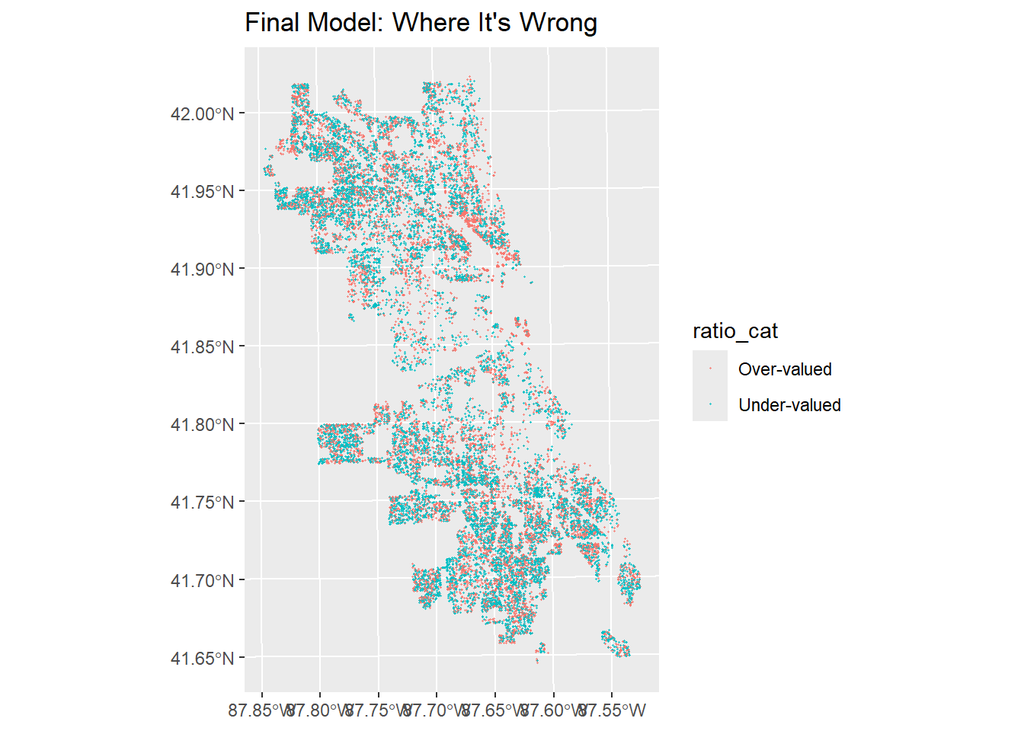

```r
train_sales_extra <- train_set|>
  mutate(m_final_pred = fitted.values(m11),
         ratio = m_final_pred/sale_price)

train_sales_extra <- train_sales_extra |>
  mutate(
    ratio_cat = case_when(
     ratio > 1 ~ "Over-valued",
     ratio < 1 ~ "Under-valued"
    ))

p_over_under_price <- ggplot(train_sales_extra) +
  geom_sf(aes(color = ratio_cat), alpha = 0.7, size = 0.2) +
  labs(
    title = "Final Model: Where It's Wrong",
    fill = "Residual"
  )

p_over_under_price
```

```r
train_sales_extra  <-  train_sales_extra %>%
  mutate(
    price_category = cut(
      sale_price,
      breaks = c(0, 180000, 469000, Inf),
      labels = c("low", "medium", "high")
    )
  )


low_price <- train_sales_extra %>%
  filter(price_category == "low") %>%
  count(ratio_cat)

high_price <- train_sales_extra %>%
  filter(price_category == "high") %>%
  count(ratio_cat)


price_ratio_table <- train_sales_extra %>%
  st_drop_geometry() %>%
  filter(price_category %in% c("low", "high")) %>%
  count(price_category, ratio_cat) %>%
  pivot_wider(
    names_from = ratio_cat,
    values_from = n,
    values_fill = 0
  )

price_ratio_table <- price_ratio_table %>%
  mutate(ratio = `Under-valued`/`Over-valued`)
price_ratio_table
```

```
# A tibble: 2 × 4
  price_category `Over-valued` `Under-valued` ratio
  <fct>                  <int>          <int> <dbl>
1 low                     3957           1783 0.451
2 high                    2651           3054 1.15
```

We divided the low / medium / high split in the same way as we did in the beginning of the assignment. We found out that lower-priced homes are indeed more likely to be over-valued, and therefore, over-taxed.

## Part 5: Predict the test houses (provided)

Refit your final recipe on all training sales, then predict every test house. Set `f_final` to your final formula.

```r
#| label: predict-test
m_final <- lm(f11, data = st_drop_geometry(train_set))

test <- all_sales %>% filter(split == "test")
#check_na(f11, st_drop_geometry(test_common))       # fill NAs; never drop test rows

preds <- tibble(id = test$id, pred = predict(m11, st_drop_geometry(test)))
sum(!is.finite(preds$pred))
```

```
[1] 0
```

```r
preds %>%
  filter(!is.finite(pred))
```

```
# A tibble: 0 × 2
# ℹ 2 variables: id <dbl>, pred <dbl>
```

```r
#test %>%
#  filter(id == 6574) %>%
#  st_drop_geometry() %>%
#  select(all_of(all.vars(formula(m11))[-1])) %>%
#  glimpse()

stopifnot(nrow(preds) == nrow(test), all(is.finite(preds$pred)))
write_csv(preds, "team_red-purple_predictions.csv")     # replace XX with your team number
```

**Final CV RMSE:** $273,141

## Part 6: Reflection

1. **Read one coefficient twice:** once as β̂, once for what it does to ŷ.

2. **Would you hand this model to the Assessor?** What would you warn them about?

Our model’s findings are consistent with the Chicago Tribune’s investigation, which found that lower-value homes were assessed at a higher proportion of their actual value than more expensive homes. In our analysis, lower-value homes had an under/overvaluation ratio of 0.451, compared with 1.152 for higher-value homes. Nevertheless, we do not recommend that the Cook County Assessor adopt this model for property assessment, as further validation and evaluation of its potential biases are needed.

Second, while our final model does seem to address issues of spatial autocorrelation from our baseline model, it over-fixes by now under-valuing a much larger share of homes.

Third, these are both indications that we are “missing something” – either demographic, spatial, or some other metric – that would help better explain sale price. On the other hand, we may have included features that though they contributed to the overall RMSE, they may not actually be useful variables going forward. For example, distance to groceries did not lower the RMSE so much and so may not be worth including in future models.

Finally, while a tax assessment model may help people lower their taxes, if it is an open source government model, it could be used by for-profit real estate companies to “game the market” in order to aquire under-taxed homes. There is no such thing as no-strings-attached in the real estate market.

### Who did what

| Name | Main contribution |
| --- | --- |
| Luca | Looked at some variables independently and contributed to the final model; reviewed file before submission |
| Jonah | Looked at some variables independently and contributed to the final model; added some reflection text |
| Rita | Looked at some variables independently and contributed to the final model; created main file |
| Ryska | Looked at some variables independently and contributed to the final model; reviewed file before submission |

### AI Team Statement

What was your team’s AI policy and how was AI used in this assignment?

We used AI for coding questions but did not really utilize AI coding in our assignment.